# R Notebook

Posts: Coulmont

[Olivier Gimenez](https://oliviergimenez.github.io/post/network_ecology/)

I am in the data <3

# Get data

```r
# Load data
thesis <- read_csv2("./2_clean_data/thesis.csv")
```

```
## Using ',' as decimal and '.' as grouping mark. Use read_delim() for more control.
```

We filter the discipline column searching for “evolut|évolut”. Sadly, the discipline names can include evolution but still be very large (such as “biological sciences and evolution”). There are also some discipline with the word “evolution” with another meaning: “evolution of terrrestrial systems” for example… So I filter out geology related fields.

We make sure that we only have thesis that were defended, and for which we know the defense date.

```r
# Theses en évolution qui ont été soutenues.
# "Evolut dans discipline : des fois, c'est beaucoup plus large. Should I do it by title?

# 638? That seem not a lot.
thesis_evolution <- thesis %>%
  filter(str_detect(discipline,
                    pattern = "Évolut|Evolut|evolut|évolut|Genetique des populations") |
           discipline == "Physiologie et biologie des organismes et populations" |
           discipline == "Biologie des populations et ecologie") %>%
  drop_na(date_defense) %>%
  filter(!str_detect(discipline,
                   pattern = "Terre|planete|lithos|geologie|Geologie|evolutionnaire|Materiaux|materiaux"))
```

We now have 1180 PhD, from 1986 to 2018.

We can look at the distribution of the year of publication: I don’t know whether the lower number of defended PhDs in the late nineties are because of a large shift towards a different name for the fields.

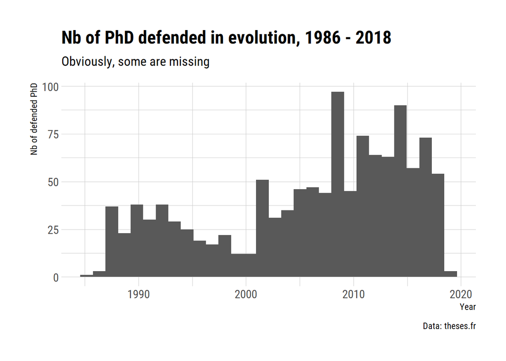

```r
thesis_evolution %>%
  ggplot(aes(x = date_defense)) +
  geom_histogram() +
  theme_ipsum_rc() +
  labs(title = "Nb of PhD defended in evolution, 1986 - 2018",
       subtitle = "Obviously, some are missing",
       x = "Year",
       y = "Nb of defended PhD",
       caption = "Data: theses.fr")
```

We filter based on the discipline, so the names are *i*) not formatted, and *ii*) change regularly even within doctoral school. It means that we are missing some PhD.

I tried to search for people I know, and quite a lot of them are in the list, but I found at least one who isn’t present as a PhD candidate.

Since I cannot filter with something as general as “biology” in the discipline, or words like “evolution” or “selection” in the title of the thesis, I will leave it as that.

One could argue that I could try to include PhD with “genetics” in the title, but I decided not to do it, to keep the sample manageable.

# Get comittes

Now that we have the ID of the PhDs in this period related to evolution, we need to get the data about the PhD committee related to these PhDs. To do that, we need to scrap the webpage of each PhD (using the PhD ID) and we use the `rvest` package again.

```r
thesis_id <- thesis_evolution$thesis_id # get PhD ids

#thesis_id <- head(thesis_id)

total_network <- data.frame(jury_members = "",
                            jury_links = "",
                            these      = "",
                            directeurs = "",
                            advisor_id = "")


for (i in 1:length(thesis_id)) {

  # get info on current PhD
  data_phd_evolution <- read_html(paste0("http://www.theses.fr/",
                                      thesis_id[i]) )

  # get name PhD supervisor for
  directeurs <- bind_cols(
    directeurs = data_phd_evolution  %>%
      html_nodes("div .donnees-ombre p") %>%
      .[[1]] %>%
      html_nodes("a") %>%
      html_text()
    ,
    advisor_id = data_phd_evolution  %>%
      html_nodes("div .donnees-ombre p") %>%
      .[[1]] %>%
      html_nodes("a") %>%
      html_attr(name="href")
  ) %>% mutate(these = thesis_id[i])


  # get names of people in commitees
  jury <- bind_cols(
    jury_members = data_phd_evolution %>%
      html_nodes("div .donnees p a") %>%
      html_text()
    ,
    jury_links = data_phd_evolution %>%
      html_nodes("div .donnees p a") %>%
      html_attr(name="href")
  ) %>% mutate(  these = thesis_id[i] )

  # put all together
  network <- jury %>% left_join(directeurs,by="these")
  total_network <- bind_rows(total_network, network)
}

# Because the process is a bit long, we save the file
save(thesis_evolution,
     total_network,
     file = "././2_clean_data/network_total.RData")
```

# Built network

Baptiste Coulmont weighted the different types of links between collegues depending on their role in the PhD process.  
- If two scientists are cosupervisor of a PhD, the link has a weight of 3, because we assume that co-supervising a PhD student creates or is the consequence of a strong link.

- If one of them is a supervisor and the other is in the PhD commitee, the link has a weight 2, indicating a moderate link.
- If both researchers are in the same committee, the link is weighted by 1.

The weight of these links can be added (a lot of people are involved both in co-supervisionsa and committes).

```r
# Link supervisor - supervisor
advisor_advisor <- total_network %>%
  select(these, directeurs) %>%
  unique() %>%
  group_by(these) %>%
  mutate(N = n()) %>%

  filter(N == 2) %>% # keep co-supervision w/ 2 supervisors
  mutate(rang  = rank(directeurs)) %>%
  spread(key   = rang,
         value = directeurs) %>%

  ungroup() %>%
  select(name_1 = `1`, name_2 = `2`) %>%
  mutate(poids = 3)


# Link advisor - jury
advisor_jury <- total_network %>%
  select(name_1 = jury_members,
         name_2 = directeurs) %>%

  filter( name_1 != "") %>%
  mutate(poids = 2) %>%
  group_by(name_1, name_2) %>%
  # Sum weight over links
  summarize(poids = sum(poids))

# Jury - jury links
jury_jury <- total_network %>%
  select(jury_members,these) %>%
  unique() %>%
  filter(jury_members != "")
```

```r
head(advisor_advisor)
```

| name_1 | name_2 | poids |
| --- | --- | --- |
| Domitien Debouzie | Frédéric Menu | 3 |
| Brigitte Crouau-Roy | Evelyne Heyer | 3 |
| François Mallet | Laurent Duret | 3 |
| Louis Deharveng | Thierry Deuve | 3 |
| Antoine Kremer | Sophie Gerber | 3 |
| Marie-Catherine Boisselier | Philippe Bouchet | 3 |

```r
head(advisor_jury)
```

| name_1 | name_2 | poids |
| --- | --- | --- |
| Abdelaziz Heddi | Fabrice Vavre | 2 |
| Abdelaziz Heddi | Frédéric Fleury | 2 |
| Abdelaziz Heddi | Mylène Weill | 2 |
| Abdelaziz Heddi | Olivier Duron | 2 |
| Abdelhamid El Mousadik | Bouchaïb Khadari | 2 |
| Abdelhamid El Mousadik | Cherkaoui El Modafar | 2 |

```r
head(jury_jury)
```

|  | jury_members | these |
| --- | --- | --- |
| 1 | Michel Boulétreau | 1988LYO10171 |
| 2 | Jean-Marc Deragon | 2010PERP1263 |
| 3 | Andrew Leitch | 2010PERP1263 |
| 4 | Alain Ghesquière | 2010PERP1263 |
| 5 | Jérôme Salse | 2010PERP1263 |
| 6 | Sébastien Aubourg | 2010PERP1263 |

Now we use the `graph_from_data_frame()` from the `igraph` package to create the graph.

```r
# Make non-directed graph for jur_jury
g_j <- graph_from_data_frame(jury_jury,
                              directed = F)


# Create the vertex sequence
igraph::V(g_j)$type <- V(g_j)$name %in% jury_jury$jury_members

g_j_1 <- bipartite_projection(g_j, which = "true")


jurys <- as_long_data_frame(g_j_1) %>%
  select(name_1 = `ver[el[, 1], ]`,
         name_2 = `ver2[el[, 2], ]`,
         poids  = weight)

reseau_petit <- bind_rows(advisor_advisor,
                          advisor_jury,
                          jurys) %>%
  group_by(name_1, name_2) %>%
  summarize(poids = sum(poids)) # data.frame from which the network will be created
```

# Plot

## Plot the full network (1986 - 2018)

```r
g <- graph_from_data_frame(reseau_petit,
                           directed = F)

g <- simplify(g, edge.attr.comb = sum)

V(g)$degres <- degree(g)

# Get surname only
V(g)$label  <- gsub("^\\S+\\s+(.+)$","\\1",V(g)$name)


# determine communities
# step = the length of the random walk to perform
V(g)$communaute <- as.character(cluster_walktrap(g,
                                                 steps = 10)$membership)  # 15 originellement

V(g)$closeness <- (5*closeness(g))^10
# network metric betweeness
V(g)$btwns       <- betweenness(g)
V(g)$eigen_centr <- eigen_centrality(g)$vector


# delete edges with weight <= 4
g <- delete_edges(g, which(E(g)$poids < 4)) # 5 initiallement



# to which community you belong
V(g)$cluster_number <- clusters(g)$membership

g <- induced_subgraph(g,
                      V(g)$cluster_number == which( max(clusters(g)$csize) == clusters(g)$csize) )

# width of edge proportional to weight
E(g)$weight <- 1/E(g)$poids


# do not display all names
V(g)$label <- ifelse(V(g)$degres < 8,
                     "",
                     V(g)$label)  # 20 initialement
```

```r
graphe_1 <- ggraph(g,
                   layout = "igraph",
                   algorithm = "fr") +

  geom_edge_link(aes(width = 0.1*poids), alpha = 0.1,
                 end_cap   = circle(5, 'mm'),
                 start_cap = circle(5, 'mm')) +

  geom_node_point(aes(size = eigen_centr),
                  color = "white", alpha = 1) +

  geom_node_point(aes(color = communaute,
                      size = eigen_centr),
                  alpha = 0.5) +

  scale_size_area(max_size = 20) +

  geom_node_text(aes(label = label),
                 size = 3,
                 repel = T,
                 box.padding = 0.15) +

  labs(title = "Réseaux des évolutionistes",
       subtitle="Soutenances de thèses entre 2015 et 2018",
       caption="Sources : theses.fr \n Code par B. Coulmont, modifié par O. Gimenez") +

  theme_graph(foreground = 'white', fg_text_colour = 'white') +

  theme(legend.position = "none",
        text = element_text(size = 16),
        plot.margin = unit(c(0.2, 0.2, 0.2, 0.2), units = "line"))

# ggsave("network1.png",
#        graphe_1,
#        units = "cm",
#        width = 30,
#        height = 25)


# png(filename = "network1.png",
#      units = "cm",
#        width = 30,
#        height = 25)
# graphe_1
# dev.off()
```

I wish I could plot more names, but my computer crashes if I try to. Every. Single. Time. So we will have to do with this level of precision, at least with the full dataset.

## Plot the network 2015 to 2018

Because the dataset was so large, it is difficult to plot more names. So let’s see what the network looks like in the past three years.

```r
source("./3_scripts/4_functions.R")
```

```r
thesis_evolution_2015_2018 <- thesis_evolution %>%
  filter(year_defense > 2014)
```

We know have a data.frame with 181 lines.

```r
scrapped_2015_2018 <- scrap_phd_webpages(thesis_evolution_2015_2018)

save(thesis_evolution_2015_2018,
     scrapped_2015_2018,
     file = "././2_clean_data/scrapped_2015_2018.RData")
```

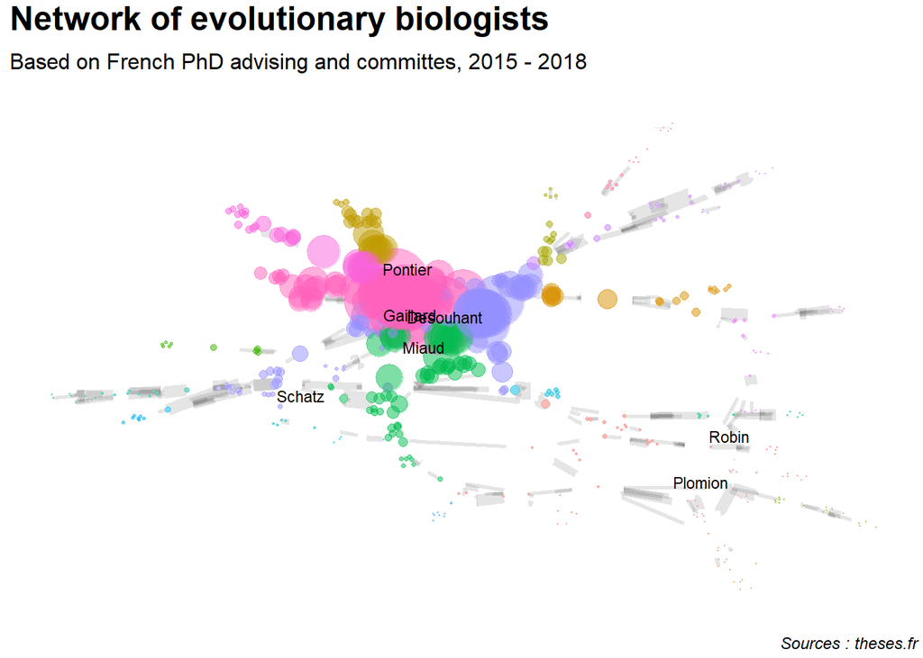

```r
graphe_2 <- make_network_full(scrapped_2015_2018,
                  my_waltrap = 10,
                  my_edge    = 3,
                  my_degree  = 4,
                  my_title   = "Network of evolutionary biologists",
                  my_subtitle = "Based on French PhD advising and committes, 2015 - 2018")
```

```r
# png(filename = "network2.png", res = 100)
#      #units = "cm", width = 30, height = 25, res = 300)
# graphe_2
# dev.off()
```

## Plot the network in Montpellier

Since I did my PhD in Montpellier, I was very curious to see the local network.

```r
thesis_evolution_Montpellier <- filter(thesis_evolution,
                             str_detect(university,
                                        pattern = "Montpellier"))
```

```r
scrapped_Montpellier <- scrap_phd_webpages(thesis_evolution_Montpellier)

save(thesis_evolution_Montpellier,
     scrapped_Montpellier,
     file = "././2_clean_data/scrapped_Montpellier.RData")
```

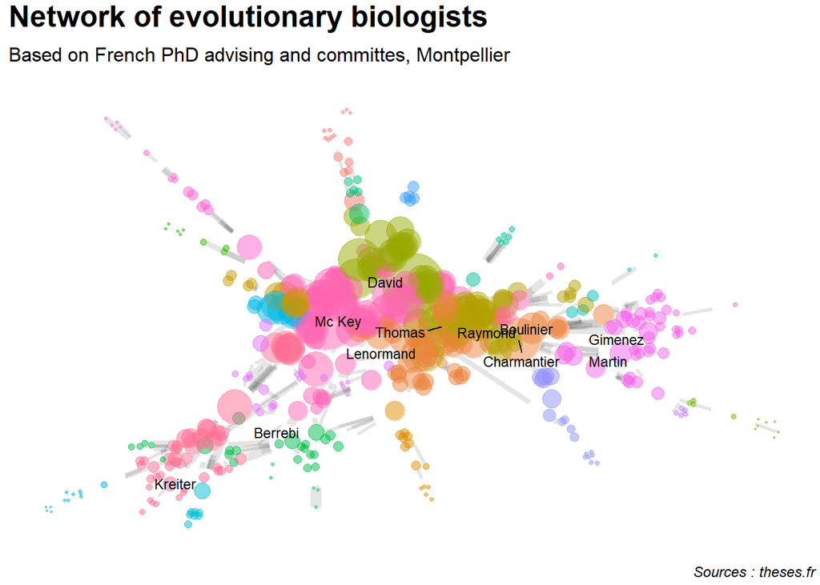

```r
graphe_3 <- make_network_full(scrapped_Montpellier,
                  my_waltrap = 7,
                  my_edge    = 1,
                  my_degree  = 2,
                  my_title   = "Network of evolutionary biologists",
                  my_subtitle = "Based on French PhD advising and committes, Montpellier")
```

```r
# png(filename = "network3.png")
#      #units = "cm", width = 30, height = 25, res = 300)
# graphe_3
# dev.off()
#
# ggsave("network3.png",
#        graphe_3,
#        units = "cm",
#        width = 30,
#        height = 25)
```